# Variational Image Deconvolution

Skip to notebook

∿Numerical Tours

← All Python tours

Download notebook[co Open in Colab](https://colab.research.google.com/github/gpeyre/numerical-tours/blob/master/python/inverse_2_deconvolution_variational.ipynb)

# Variational Image Deconvolution

Recover an image from a blurred observation by balancing data fidelity with a regularity penalty. Follow the optimization iterates and compare reconstructions to understand why direct inversion amplifies noise.

## Run this tour

Run the cells in order with a Python 3 kernel. The first cell locates the companion data and toolbox and installs missing dependencies when needed. All worked examples include their implementation directly in this notebook. Random seeds make comparisons reproducible; you can change them to explore other samples.

```python
# Locate the companion toolbox locally, or fetch it for a standalone/Colab copy.
from pathlib import Path
import importlib.util
import os
import subprocess
import sys

working = Path.cwd()
candidates = [working, working / "python", working.parent / "python"]
python_dir = next((p for p in candidates if (p / "nt_toolbox").is_dir()), None)
if python_dir is None:
    checkout = working / "numerical-tours-support"
    if not checkout.exists():
        subprocess.run(
            [
                "git",
                "clone",
                "--depth",
                "1",
                "--branch",
                "master",
                "https://github.com/gpeyre/numerical-tours.git",
                str(checkout),
            ],
            check=True,
        )
    python_dir = checkout / "python"
os.chdir(python_dir)
if str(python_dir) not in sys.path:
    sys.path.insert(0, str(python_dir))
requirements = python_dir / "requirements.txt"
if any(
    importlib.util.find_spec(name) is None
    for name in [
        "numpy",
        "scipy",
        "matplotlib",
        "skimage",
        "sklearn",
        "pywt",
        "ipywidgets",
        "cvxpy",
        "skfmm",
        "autograd",
        "progressbar",
        "celer",
    ]
):
    subprocess.run(
        [sys.executable, "-m", "pip", "install", "-r", str(requirements)], check=True
    )

import numpy as np
import matplotlib.pyplot as plt

np.random.seed(0)
plt.rcParams.update(
    {
        "figure.figsize": (8, 4),
        "figure.dpi": 100,
        "axes.spines.top": False,
        "axes.spines.right": False,
        "font.size": 11,
        "image.cmap": "gray",
    }
)
%matplotlib inline
```

This numerical tour explores the use of Sobolev and TV regularization to perform image deconvolution.

$\newcommand{\dotp}[2]{\langle #1, #2 \rangle}$ $\newcommand{\enscond}[2]{\lbrace #1, #2 \rbrace}$ $\newcommand{\pd}[2]{ \frac{ \partial #1}{\partial #2} }$ $\newcommand{\umin}[1]{\underset{#1}{\min}\;}$ $\newcommand{\umax}[1]{\underset{#1}{\max}\;}$ $\newcommand{\uargmin}[1]{\underset{#1}{argmin}\;}$ $\newcommand{\norm}[1]{\|#1\|}$ $\newcommand{\abs}[1]{\left|#1\right|}$ $\newcommand{\choice}[1]{ \left\{ \begin{array}{l} #1 \end{array} \right. }$ $\newcommand{\pa}[1]{\left(#1\right)}$ $\newcommand{\diag}[1]{{diag}\left( #1 \right)}$ $\newcommand{\qandq}{\quad\text{and}\quad}$ $\newcommand{\qwhereq}{\quad\text{where}\quad}$ $\newcommand{\qifq}{ \quad \text{if} \quad }$ $\newcommand{\qarrq}{ \quad \Longrightarrow \quad }$ $\newcommand{\ZZ}{\mathbb{Z}}$ $\newcommand{\CC}{\mathbb{C}}$ $\newcommand{\RR}{\mathbb{R}}$ $\newcommand{\EE}{\mathbb{E}}$ $\newcommand{\Zz}{\mathcal{Z}}$ $\newcommand{\Ww}{\mathcal{W}}$ $\newcommand{\Vv}{\mathcal{V}}$ $\newcommand{\Nn}{\mathcal{N}}$ $\newcommand{\NN}{\mathcal{N}}$ $\newcommand{\Hh}{\mathcal{H}}$ $\newcommand{\Bb}{\mathcal{B}}$ $\newcommand{\Ee}{\mathcal{E}}$ $\newcommand{\Cc}{\mathcal{C}}$ $\newcommand{\Gg}{\mathcal{G}}$ $\newcommand{\Ss}{\mathcal{S}}$ $\newcommand{\Pp}{\mathcal{P}}$ $\newcommand{\Ff}{\mathcal{F}}$ $\newcommand{\Xx}{\mathcal{X}}$ $\newcommand{\Mm}{\mathcal{M}}$ $\newcommand{\Ii}{\mathcal{I}}$ $\newcommand{\Dd}{\mathcal{D}}$ $\newcommand{\Ll}{\mathcal{L}}$ $\newcommand{\Tt}{\mathcal{T}}$ $\newcommand{\si}{\sigma}$ $\newcommand{\al}{\alpha}$ $\newcommand{\la}{\lambda}$ $\newcommand{\ga}{\gamma}$ $\newcommand{\Ga}{\Gamma}$ $\newcommand{\La}{\Lambda}$ $\newcommand{\Si}{\Sigma}$ $\newcommand{\be}{\beta}$ $\newcommand{\de}{\delta}$ $\newcommand{\De}{\Delta}$ $\newcommand{\phi}{\varphi}$ $\newcommand{\th}{\theta}$ $\newcommand{\om}{\omega}$ $\newcommand{\Om}{\Omega}$

```python
from nt_toolbox.general import clamp, transform
from nt_toolbox.signal import div, grad, imageplot, load_image, snr, transform
import numpy as np
import matplotlib.pyplot as plt
from numpy import (
    abs,
    arange,
    argmax,
    concatenate,
    e,
    exp,
    gradient,
    linspace,
    meshgrid,
    real,
    repeat,
    resize,
    sqrt,
    sum,
    zeros,
)
from matplotlib.pyplot import axis, clf, matplotlib, plot, step, xlabel, ylabel
from numpy.linalg import norm
from numpy.fft import fft2, fftshift, ifft2
from numpy.random import randn

%matplotlib inline
```

This tour is concerned with the deconvolution problem. The measurement are assumed to be blurry and noisy: $$y=\Phi f_0 + w = h \star f_0 + w$$

Where here |h| is the filter (low pass) and |w| some noise (here assumed to be white Gaussian).

We consider variational deconvolution methods, that finds a regularizer through a convex optimization: $$f^\star \in \text{argmin}_f \frac{1}{2}\|y-\Phi f\|^2 + \lambda J(f)$$

Where $J(f)$ is a prior energy. In this tour we consider a simple L2 prior (the image is assumed to have a bounded energy), a Sobolev prior (the image is uniformly smooth) and an approximate total variation (the image has edges of bounded perimeter).

Note that the parameter $\lambda$ should be carefully chosen to fit the noise level.

## Image Blurring

Deconvolution corresponds to removing a blur from an image. We use here a Gaussian blur.

First we load the image to be inpainted.

```python
n = 256
name = "nt_toolbox/data/hibiscus.bmp"
f0 = load_image(name, n);
```

Initial image $f_0$.

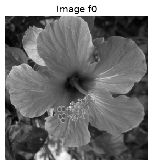

```python
imageplot(f0, "Image f0", [1, 2, 1])
```

We build a convolution kernel. Since we are going to use Fourier to compute the convolution, we set the center of the kernel in the (1,1) pixel location.

Width $s$ of the kernel, in pixel.

```python
s = 3
```

Define the convolution kernel $h$.

```python
x = concatenate((arange(0, n / 2), arange(-n / 2, 0)))
[Y, X] = meshgrid(x, x)
h = exp((-(X**2) - Y**2) / (2 * s**2))
h = h / sum(h.flatten())
```

Useful for later : the Fourier transform (should be real because of symmetry).

```python
hF = real(fft2(h))
```

Display the kernel and its transform. We use |fftshift| to center the filter for display.

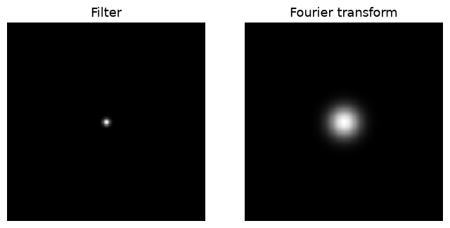

```python
imageplot(fftshift(h), "Filter", [1, 2, 1])
imageplot(fftshift(hF), "Fourier transform", [1, 2, 2])
```

We use this short hand for the filtering. Note that this is a symmetric operator.

```python
Phi = lambda x, h: real(ifft2(fft2(x) * fft2(h)))
```

*Important* Scilab user should define a function |Phi| in a separate file |Phi.sci| to perform this.

Apply the filter.

```python
y0 = Phi(f0, h)
```

Display the filtered observation.

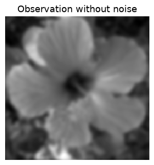

```python
imageplot(y0, "Observation without noise", [1, 2, 2])
```

Variance $\sigma^2$ of the noise $w$.

```python
sigma = 0.02
```

Add some noise to obtain the measurements $y = \Phi f_0 + w$.

```python
y = y0 + randn(n, n) * sigma
```

Display.

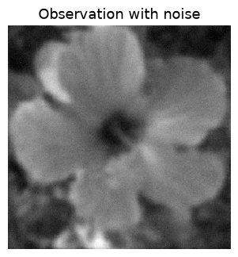

```python
imageplot(clamp(y), "Observation with noise", [1, 2, 2])
```

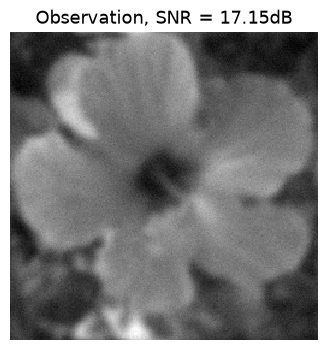

```python
imageplot(y, "Observation, SNR = " + str(round(snr(f0, y), 2)) + "dB")
```

## Deconvolution with L2 Regularization

Deconvolution is obtained by dividing the Fourier transform of $y$ by $\hat h$. $$f^\star(\omega) = \frac{\hat y(\omega)}{\hat h(\omega)} = \hat f_0(\omega) + \hat w(\omega)/{\hat h(\omega)}$$

Unfortunately this creates an explosion of the Noise.

To avoid this explosion, we consider a simple regularization. $$f^{\star} = \text{argmin}_f \: \|y-\Phi f\|^2 + \lambda \|f\|^2$$

Since the filtering is diagonalized over Fourier, the solution is simply computed over the Fourier domain as: $$\hat f^\star(\omega) = \frac{\hat y(\omega) \hat h(\omega)}{ \|\hat h(\omega)\|^2 + \lambda }$$

Useful for later: Fourier transform of the observations.

```python
yF = fft2(y)
```

Select a value for the regularization parameter.

```python
Lambda = 0.02
```

Perform the inversion.

```python
fL2 = real(ifft2(yF * hF / (abs(hF) ** 2 + Lambda)))
```

Display.

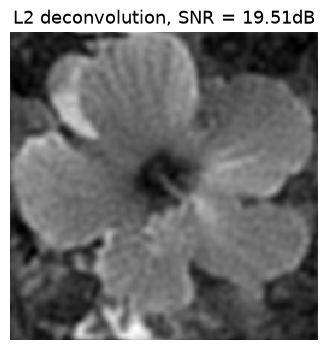

```python
imageplot(clamp(fL2), "L2 deconvolution, SNR = " + str(round(snr(f0, fL2), 2)) + "dB")
```

**Worked example 1:** Find the optimal solution fL2 by testing several value of $\lambda$.

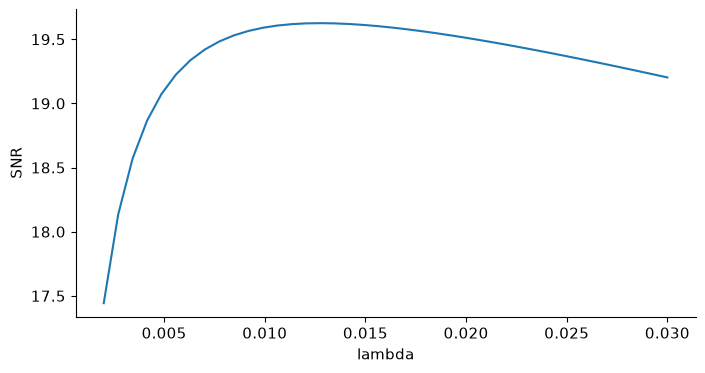

```python
lambda_list = linspace(2 * 1e-3, 0.03, 40)
err = zeros((len(lambda_list), 1))
for i in arange(0, len(lambda_list)):
    Lambda = lambda_list[i]
    fL2 = real(ifft2(yF * hF / (abs(hF) ** 2 + Lambda)))
    err[i] = snr(f0, fL2)
clf
plot(lambda_list, err)
axis("tight")
xlabel("lambda")
ylabel("SNR")

i = argmax(err)
Lambda = lambda_list[i]
fL2 = real(ifft2(yF * hF / (abs(hF) ** 2 + Lambda)))
```

Display optimal result.

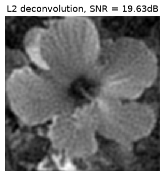

```python
imageplot(clamp(fL2), "L2 deconvolution, SNR = " + str(round(snr(f0, fL2), 2)) + "dB")
```

## Deconvolution by Sobolev Regularization.

L2 regularization did not perform any denoising. To remove some noise, we can penalize high frequencies using Sobolev regularization (quadratic grow).

The Sobolev prior reads (note the conversion from spacial domain to Fourier domain) $$J(f) = \sum_x \|\nabla f(x)\|^2 = \sum_{\omega} S(\omega) \|\hat f(\omega)\|^2 $$ where $S(\omega)=\|\omega\|^2$.

Since this prior can be written over the Fourier domain, one can compute the solution to the deblurring with Sobolev prior simply with the Fourier coefficients: $$\hat f^\star(\omega) = \frac{\hat y(\omega) \hat h(\omega)}{ \|\hat h(\omega)\|^2 + \lambda S(\omega) }$$

Compute the Sobolev prior penalty |S|(rescale to [0,1]).

```python
S = (X**2 + Y**2) * (2 / n) ** 2
```

Regularization parameter:

```python
Lambda = 0.2
```

Perform the inversion.

```python
fSob = real(ifft2(yF * hF / (abs(hF) ** 2 + Lambda * S)))
```

Display the result.

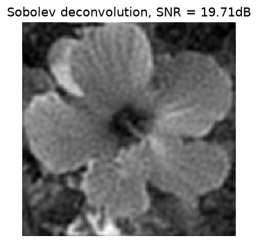

```python
imageplot(
    clamp(fSob), "Sobolev deconvolution, SNR = " + str(round(snr(f0, fSob), 2)) + "dB"
)
```

**Worked example 2:** Find the optimal solution fSob by testing several value of $\lambda$.

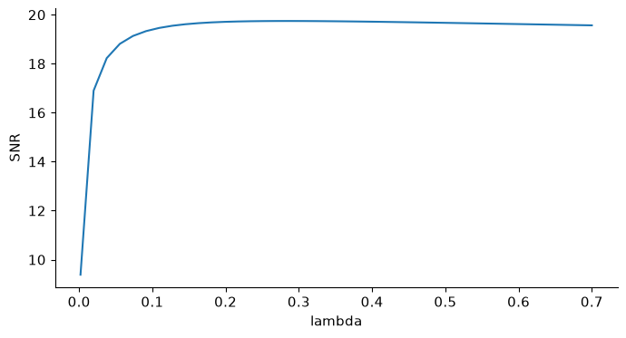

```python
lambda_list = linspace(2 * 1e-3, 0.7, 40)
err = zeros((len(lambda_list), 1))
for i in arange(0, len(lambda_list)):
    Lambda = lambda_list[i]
    fSob = real(ifft2(yF * hF / (abs(hF) ** 2 + Lambda * S)))
    err[i] = snr(f0, fSob)
clf
plot(lambda_list, err)
axis("tight")
xlabel("lambda")
ylabel("SNR")

i = argmax(err)
Lambda = lambda_list[i]
fSob = real(ifft2(yF * hF / (abs(hF) ** 2 + Lambda * S)))
```

Display optimal result.

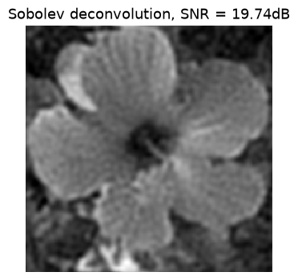

```python
imageplot(
    clamp(fSob), "Sobolev deconvolution, SNR = " + str(round(snr(f0, fSob), 2)) + "dB"
)
```

## Deconvolution by Total Variation Regularization

Sobolev regularization perform a denoising but also tends to blur the edges, thus producing a poor results on cartoon images.

The TV prior is able to better reconstruct sharp edges. It reads: $$J(f) = \sum_x \| \nabla f(x)\|$$

With respect to the Sobolev energy, it simply corresponding to measuring the L1 norm instead of the L2 norm, thus dropping the square in the functional.

Unfortunately, the TV functional $J(f)$ is not a smooth function of the image $f$. It thus requires the use of advanced convex optimization method to be minimized for regularization.

An alternative is to replace the absolute value by a smooth absolute value. The smoothed TV norm reads: $$J(f) = \sum_x \sqrt{\|\nabla f(x)\|^2+\varepsilon^2}$$

Regularization parameter for the TV norm:

```python
epsilon = 0.4 * 1e-2
```

When $\epsilon$ gets close to zero, the smoothed energy becomes closer to the original total variation, but the optimization becomes more difficult. When |epsilon| becomes large, the smoothed energy becomes closer to the Sobolev energy, thus blurring the edges.

Unfortunately, this prior is non-quadratic, and cannot be expressed over the Fourier domain. One thus need to use an iterative scheme such as a gradient descent to approximate the solution.

An iteration of the gradient descent reads: $$f^{(k+1)} = f^{(k)} - \tau \left( h \star (h \star f^{(k)} - y) + \lambda \text{Grad} J(f^{(k)}) \right)$$

Regularization parameter.

```python
Lambda = 0.06
```

The value of $\tau$, the step size, should be smaller than twice the Lipschitz constant of the Gradient of the functional to be minimized, hence: $$ \tau< \frac{2}{1 + \lambda 8/\varepsilon }.$$

```python
tau = 1.9 / (1 + Lambda * 8 / epsilon)
```

Initialization.

```python
fTV = y
```

Number of iteration (quite a large number is required).

```python
niter = 300
```

We first check that the discretized grad and -div are adjoint one of each other.

```python
a = randn(n, n)
b = randn(n, n, 2)
dotp = lambda x, y: sum(x.flatten() * y.flatten())
print("Should be 0: " + str(dotp(grad(a), b) + dotp(a, div(b))))
```

```
Should be 0: 1.1368683772161603e-13
```

The gradient of the smoothed TV energy is: $$\text{Grad} J(f) = -\text{div}\left( \frac{\nabla f}{ \sqrt{\|\nabla f\|^2+\varepsilon^2} } \right)$$

Compute the gradient of the smoothed TV functional.

```python
repeat3 = lambda x, k: resize(repeat(x, k, axis=1), [n, n, k])
Gr = grad(fTV)
d = sqrt(epsilon**2 + sum(Gr**2, axis=2))
G = -div(Gr / repeat3(d, 2))
```

Compute the TV norm, usefull to keep track of its decay through iterations.

```python
tv = sum(d.flatten())
print("Smoothed TV norm of the image: " + str(round(tv, 2)))
```

```
Smoothed TV norm of the image: 2474.3
```

Perform a step of gradient descent for the inversion.

```python
e = Phi(fTV, h) - y
fTV = fTV - tau * (Phi(e, h) + Lambda * G)
```

**Worked example 3:** Perform the deblurring by a gradient descent. Keep track of the function being minimized.

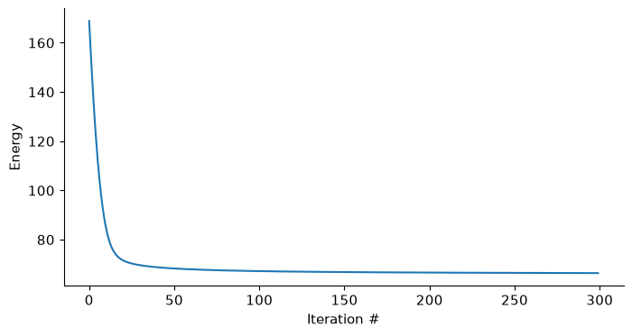

```python
tau = 1.9 / (1 + Lambda * 8 / epsilon)
fTV = y
E = zeros((niter, 1))
for i in arange(0, niter):
    # Compute the gradient of the smoothed TV functional.
    Gr = grad(fTV)
    d = sqrt(epsilon**2 + sum(Gr**2, axis=2))
    G = -div(Gr / repeat3(d, 2))
    # step
    e = Phi(fTV, h) - y
    fTV = fTV - tau * (Phi(e, h) + Lambda * G)
    # energy
    E[i] = 1 / 2 * norm(e.flatten()) ** 2 + Lambda * sum(d.flatten())
# display energy
clf
plot(E)
axis("tight")
xlabel("Iteration #")
ylabel("Energy")
```

Display the result.

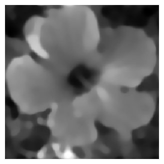

```python
imageplot(clamp(fTV))
```

### Worked example 4

Explore the different values of |lambda| to find the optimal solution. Display the SNR as a function of |lambda|.

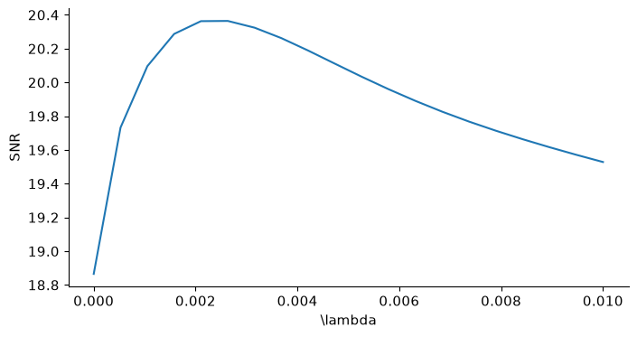

```python
niter = 300
lambda_list = linspace(1e-6, 0.01, 20)
tau = 1.9 / (1 + max(lambda_list) * 8 / epsilon)
fBest = y
fTV = y
err = zeros((len(lambda_list), 1))
for it in arange(0, len(lambda_list)):
    # print('.',end="",flush=True)
    Lambda = lambda_list[it]
    for i in arange(0, niter):
        # Compute the gradient of the smoothed TV functional.
        Gr = grad(fTV)
        d = sqrt(epsilon**2 + sum(Gr**2, axis=2))
        G = -div(Gr / repeat3(d, 2))
        # step
        e = Phi(fTV, h) - y
        fTV = fTV - tau * (Phi(e, h) + Lambda * G)
    err[it] = snr(f0, fTV)
    if err[it] > snr(f0, fBest):
        fBest = fTV
clf
plot(lambda_list, err)
axis("tight")
xlabel(r"\lambda")
ylabel("SNR")
fTV = fBest
```

Display the result.

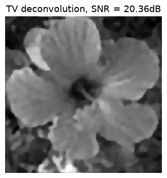

```python
imageplot(
    clamp(fBest), "TV deconvolution, SNR = " + str(round(snr(f0, fBest), 2)) + "dB"
)
```

## References and further reading

- Leonid Rudin, Stanley Osher, and Emad Fatemi. Nonlinear Total Variation Based Noise Removal Algorithms. 1992, Physica D 60, 259–268. The foundational total-variation image restoration model.
- Neal Parikh and Stephen Boyd. [Proximal Algorithms](https://web.stanford.edu/~boyd/papers/prox_algs.html). 2014, Foundations and Trends in Optimization 1(3), 127–239. Proximity operators and splitting methods for nonsmooth objectives.
- Amir Beck and Marc Teboulle. [A Fast Iterative Shrinkage-Thresholding Algorithm for Linear Inverse Problems](https://doi.org/10.1137/080716542). 2009, SIAM Journal on Imaging Sciences 2(1), 183–202. Accelerated proximal gradient descent and its convergence rate.
- Antonin Chambolle and Thomas Pock. [A First-Order Primal-Dual Algorithm for Convex Problems with Applications to Imaging](https://doi.org/10.1007/s10851-010-0251-1). 2011, Journal of Mathematical Imaging and Vision 40, 120–145. Primal–dual splitting for total variation and other composite penalties.
- Stéphane Mallat. [A Wavelet Tour of Signal Processing: The Sparse Way](https://www.di.ens.fr/~mallat/biblio.html). 2009, 3rd ed., Academic Press. Multiresolution analysis, sparse approximation, and wavelet algorithms.
- Stephen Boyd and Lieven Vandenberghe. [Convex Optimization](https://web.stanford.edu/~boyd/cvxbook/). 2004, Cambridge University Press. Convexity, duality, optimality conditions, and interior-point methods.

**On this page**